# House Prices Analysis

Tonatiuh De Leon

```r
library(tidyverse)
library(pander)
library(gridExtra)
library(DT)
library(grid)
library(knitr)
library(formattable)
```

```r
dt <- read_csv("train.csv") |>
  rename(bsm = "TotalBsmtSF",
         `1s` = "1stFlrSF",
         `2n` = "2ndFlrSF",
         oq = "OverallQual",
         sp = "SalePrice",
         oc = "OverallCond",
         rm ="TotRmsAbvGrd",
         bld ="BldgType",
         exq = "ExterQual",
         exc = "ExterCond",
         bdr = "BedroomAbvGr") |>
  mutate(tsf = `1s` + `2n` + bsm,
         nbd = case_when(Neighborhood %in% c("StoneBr", "NridgHt", "NoRidge") ~ 1, TRUE ~ 0),
         tsf1 = ifelse(tsf>7500, 2567, tsf),
         bld1 = case_when(bld %in% c("TwnhsE", "1Fam") ~ 1, TRUE ~ 0),
         exq = as.character(exq),
         exq = case_when(exq == "Ex" ~ 10, exq == "Gd" ~ 8,
                         exq == "TA" ~ 6, exq == "Fa" ~ 4,
                         exq == "Po" ~ 2, TRUE ~ NA_integer_),
         exq = as.numeric(exq),
         exc = as.character(exc),
         exc = case_when(exc == "Ex" ~ 10, exc == "Gd" ~ 8,
                                exc == "TA" ~ 6, exc == "Fa" ~ 4,
                                exc == "Po" ~ 2, TRUE ~ NA_integer_),
         exc = as.numeric(exc),
         oq1 = case_when(oq %in% c(1,2,3, 4) ~ 4, TRUE ~ oq),
         bdr1 = case_when(bdr > 3 ~ 1, TRUE ~ 0),
         occ = oq+exq+exc+oc,
         oc1 = ceiling((oq+exq+exc+oc)/4),
         oc2 = case_when(oc1 > 6 ~ 1, TRUE ~ 0),
         kq = as.character(KitchenQual),
         kq = case_when(kq == "Ex" ~ 1, kq == "Gd" ~ 2,
                         kq == "TA" ~ 3, kq == "Fa" ~ 4,
                         kq == "Po" ~ 5, TRUE ~ NA_integer_),
         kq = as.numeric(kq),
         kq1 = case_when(kq < 3 ~ 1, TRUE ~ 0),
         bth = BsmtFullBath+BsmtHalfBath+FullBath+HalfBath,
         sc = case_when(SaleCondition %in% c("Partial","Alloca","Normal") ~ 1, TRUE ~ 0),
         ht = case_when(HeatingQC == "Ex" ~ 1, HeatingQC == "Gd" ~ 2,
                         HeatingQC == "TA" ~ 3, HeatingQC == "Fa" ~ 4,
                         HeatingQC == "Po" ~ 5, TRUE ~ NA_integer_),
         Alley = as.character(Alley),
         al = replace_na(Alley, "no"),
         al = case_when(al == "no" ~ 0, TRUE ~ 1),
         al = as.numeric(al),
         Utilities = as.character(Utilities),
         ut = case_when(Utilities == c("AllPub","NoSewr") ~ 1, TRUE ~ 0),
         ut = as.numeric(ut),
         fp = case_when(Fireplaces > 0 ~ 1, TRUE ~ 0),
         GarageFinish = as.character(GarageFinish),
         gr = replace_na(GarageFinish, "no"),
         gr = case_when(gr == "no" ~ 0, TRUE ~ 1),
         gr = as.numeric(gr),
         PoolQC = as.character(PoolQC),
         pl = replace_na(PoolQC, "no"),
         pl = case_when(pl == "no" ~ 0, TRUE ~ 1),
         pl = as.numeric(pl),
         Fence = as.character(Fence),
         fnc = replace_na(Fence, "no"),
         fnc = case_when(fnc == "no" ~ 0, TRUE ~ 1),
         fnc = as.numeric(fnc))

dt10 <- dt |>
  filter(oq1 == 10)

dt9 <- dt |>
  filter(oq1 == 9)

dt8 <- dt |>
  filter(oq1 == 8)

dt7 <- dt |>
  filter(oq1 == 7)

dt6 <- dt |>
  filter(oq1 == 6)

dt5 <- dt |>
  filter(oq1 == 5)

dt4 <- dt |>
  filter(oq1 == 4)

dtg <- dt |>
  rename(`Overall Quality` = oq1) |>
  group_by(`Overall Quality`) |>
  summarise(
    `Lot Area` = round(mean(LotArea)),
    `Neighborhoods` = round(mean(nbd)),
    #`Overall Quality` = round(mean(oc1)),
    `Building Type` = round(mean(bld1)),
    `Kitchen Quality` = round(mean(kq)),
    `Bathrooms` = round(mean(bth)),
    `Bedrooms` = round(mean(bdr)),
    `Sale Condition` = round(mean(sc)),
    `Heating Quality` = round(mean(ht)),
    `Garage` = round(mean(gr)),
    `fireplace` = round(mean(fp))) |>
  arrange(desc(`Overall Quality`))


mylm <- lm(sp ~  nbd + tsf1:oq + tsf1:oc1 + tsf1:nbd + bld1 + tsf1:kq + tsf1:bth + bdr + tsf1:bdr + sc + tsf1:ht + al + gr + tsf1:fp + LotArea , data=dt)
b <- coef(mylm)
```

## Total Square Feet Analysis

#### Introduction

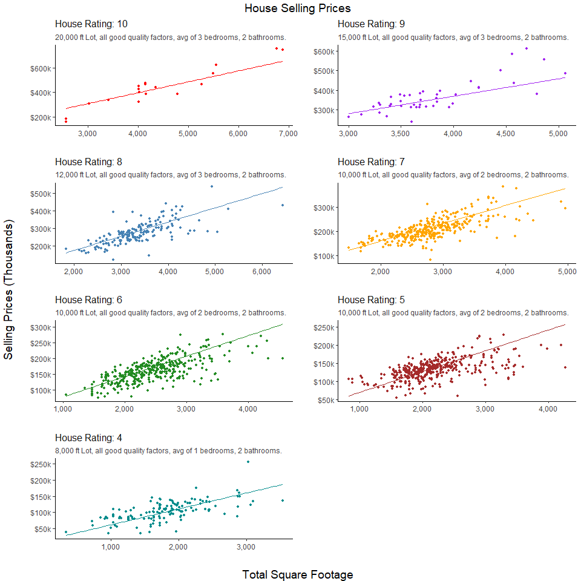

```r
g10 <- ggplot(dt10, aes(tsf1,sp))+

  geom_point(cex=.9, col="red", fill="white") +

  scale_y_continuous(breaks = c(200000, 400000, 600000), labels=c("$200k","$400k","$600k"))+

  scale_x_continuous(breaks = c(3000, 4000, 5000, 6000, 7000), labels = c("3,000", "4,000", "5,000", "6,000", "7,000"))+

  stat_function(fun=function(x, oq1=10)

    (b[1]#int
     + b[2]*mean(dt10$nbd)#nbd
     + b[3]*mean(dt10$bld1)#building type
     + b[4]*3#bedr
     + b[5]*mean(dt10$sc)#sc
     + b[6]*mean(dt10$al)#alley
     + b[7]*mean(dt10$gr)#gara
     + b[8]*mean(dt10$LotArea)) +

    (b[9]*10 #oq
     + b[10]*10 #oc1
     + b[11]*mean(dt10$nbd) #nbd
     + b[12]*mean(dt10$kq) #kq
     + b[13]*2 #bath
     + b[14]*3 #bdr
     + b[15]*mean(dt10$ht) #ht
     + b[16]*mean(dt10$fp) #fp
     )*x, col="red") +

  theme_classic() +

  labs(
    title = "House Rating: 10",
    subtitle = "20,000 ft Lot, all good quality factors, avg of 3 bedrooms, 2 bathrooms.",
    x= "",
    y = "") +

  theme(
    plot.title = element_text(size=12, color = "grey5"),
    axis.text.x = element_text(color = "grey25"),
    axis.text.y = element_text(color = "grey25"),
    plot.subtitle = element_text(color = "grey25",   size=9))



g9 <- ggplot(dt9, aes(tsf1,sp))+

  geom_point(cex=.9, col="purple", fill="white") +

  scale_y_continuous(breaks = c(300000, 400000, 500000, 600000), labels=c("$300k","$400k","$500k","$600k"))+

  scale_x_continuous(breaks = c(3000, 3500, 4000, 4500, 5000), labels = c("3,000", "3,500", "4,000", "4,500", "5,000"))+

  stat_function(fun=function(x, oq1=9)

    (b[1] + b[2]*1 + b[3]*1 + b[4]*3 + b[5]*1 + b[6]*1 + b[7]*1 + b[8]*13500) +

    (b[9]*oq1 + b[10]*oq1 + b[11]*1 + b[12]*1 + b[13]*2 + b[14]*3 + b[15]*1 + b[16]*1)*x, col="purple") +

  theme_classic() +

  labs(
    title = "House Rating: 9",
    subtitle = "15,000 ft Lot, all good quality factors, avg of 3 bedrooms, 2 bathrooms.",
    x = "",
    y = "")  +

  theme(
    plot.title = element_text(size=12, color = "grey5"),
    axis.text.x = element_text(color = "grey25"),
    axis.text.y = element_text(color = "grey25"),
    plot.subtitle = element_text(color = "grey25",   size=9))

g8 <- ggplot(dt8, aes(tsf1,sp))+

  geom_point(cex=.9, col="steelblue", fill="white") +

  scale_y_continuous(breaks = c(200000, 300000, 400000, 500000), labels=c("$200k","$300k", "$400k","$500k"))+

  scale_x_continuous(breaks = c( 2000, 3000, 4000, 5000, 6000), labels = c("2,000", "3,000", "4,000", "5,000", "6,000"))+

  stat_function(fun=function(x, oq1=8)

    (b[1] + b[2]*1 + b[3]*1 + b[4]*3 + b[5]*1 + b[6]*1 + b[7]*1 + b[8]*10000) +

    (b[9]*oq1 + b[10]*oq1 + b[11]*1 + b[12]*1 + b[13]*2 + b[14]*3 + b[15]*1 + b[16]*1)*x, col="steelblue") +

  theme_classic() +

  labs(
    title = "House Rating: 8",
    x = "",
    y = "",
    subtitle = "12,000 ft Lot, all good quality factors, avg of 3 bedrooms, 2 bathrooms.") +

  theme(
    plot.title = element_text(size=12, color = "grey5"),
    axis.text.x = element_text(color = "grey25"),
    axis.text.y = element_text(color = "grey25"),
    plot.subtitle = element_text(color = "grey25",   size=9))


g7 <- ggplot(dt7, aes(tsf1,sp))+

  geom_point(cex=.9, col="orange", fill="white") +

  scale_y_continuous(breaks = c(100000, 200000, 300000, 400000), labels=c("$100k","$200k","$300k","$400k"))+

  scale_x_continuous(breaks = c( 2000, 3000, 4000, 5000), labels = c("2,000", "3,000", "4,000", "5,000"))+

  stat_function(fun=function(x, oq1=7)

    (b[1] + b[2]*1 + b[3]*1 + b[4]*3 + b[5]*1 + b[6]*1 + b[7]*1 + b[8]*11000) +

    (b[9]*oq1 + b[10]*oq1 + b[11]*1 + b[12]*1 + b[13]*2 + b[14]*3 + b[15]*1 + b[16]*1)*x, col="orange") +

  theme_classic() +

  labs(
    title = "House Rating: 7",
    x = "",
    y = "",
    subtitle = "10,000 ft Lot, all good quality factors, avg of 2 bedrooms, 2 bathrooms.") +

  theme(
    plot.title = element_text(size=12, color = "grey5"),
    axis.text.x = element_text(color = "grey25"),
    axis.text.y = element_text(color = "grey25"),
    plot.subtitle = element_text(color = "grey25",   size=9))

g6 <- ggplot(dt6, aes(tsf1,sp))+

  geom_point(cex=.9, col="forestgreen", fill="white") +

  scale_y_continuous(breaks = c(100000, 150000, 200000, 250000, 300000), labels=c("$100k", "$150k", "$200k", "$250k","$300k"))+

  scale_x_continuous(breaks = c( 1000, 2000, 3000, 4000), labels = c("1,000", "2,000", "3,000", "4,000"))+

  stat_function(fun=function(x, oq1=6)

    (b[1] + b[2]*1 + b[3]*1 + b[4]*3 + b[5]*1 + b[6]*1 + b[7]*1 + b[8]*10000) +

    (b[9]*oq1 + b[10]*oq1 + b[11]*1 + b[12]*1 + b[13]*2 + b[14]*3 + b[15]*1 + b[16]*1)*x, col="forestgreen") +

  theme_classic() +

  labs(
    title = "House Rating: 6",
    x = "",
    y = "",
    subtitle = "10,000 ft Lot, all good quality factors, avg of 2 bedrooms, 2 bathrooms.") +

  theme(
    plot.title = element_text(size=12, color = "grey5"),
    axis.text.x = element_text(color = "grey25"),
    axis.text.y = element_text(color = "grey25"),
    plot.subtitle = element_text(color = "grey25",   size=9))

g5 <- ggplot(dt5, aes(tsf1,sp))+

  geom_point(cex=.9, col="brown", fill="white") +

  scale_y_continuous(breaks = seq(50000,250000, by=50000), labels=c("$50k", "$100k", "$150k", "$200k", "$250k"))+

  scale_x_continuous(breaks = c( 1000, 2000, 3000, 4000), labels = c("1,000", "2,000", "3,000", "4,000"))+

  stat_function(fun=function(x, oq1=5)

    (b[1] + b[2]*1 + b[3]*1 + b[4]*3 + b[5]*1 + b[6]*1 + b[7]*1 + b[8]*10000) +

    (b[9]*oq1 + b[10]*oq1 + b[11]*1 + b[12]*1 + b[13]*2 + b[14]*3 + b[15]*1 + b[16]*1)*x, col="brown") +

  theme_classic() +

  labs(
    title = "House Rating: 5",
    x = "",
    y = "",
    subtitle = "10,000 ft Lot, all good quality factors, avg of 2 bedrooms, 2 bathrooms.") +

  theme(
    plot.title = element_text(size=12, color = "grey5"),
    axis.text.x = element_text(color = "grey25"),
    axis.text.y = element_text(color = "grey25"),
    plot.subtitle = element_text(color = "grey25",   size=9))

g4 <- ggplot(dt4, aes(tsf1,sp))+

  geom_point(cex=.9, col="cyan4", fill="white") +

  scale_y_continuous(breaks = seq(50000,250000, by=50000), labels=c("$50k", "$100k", "$150k", "$200k", "$250k"))+

  scale_x_continuous(breaks = c( 1000, 2000, 3000), labels = c("1,000", "2,000", "3,000"))+

  stat_function(fun=function(x, oq1=4)

    (b[1] + b[2]*1 + b[3]*1 + b[4]*3 + b[5]*1 + b[6]*1 + b[7]*1 + b[8]*8000) +

    (b[9]*oq1 + b[10]*oq1 + b[11]*1 + b[12]*1 + b[13]*2 + b[14]*3 + b[15]*1 + b[16]*1)*x, col="cyan4") +

  theme_classic() +

  labs(
    title = "House Rating: 4",
    x = "",
    y = "",
    subtitle = "8,000 ft Lot, all good quality factors, avg of 1 bedrooms, 2 bathrooms.") +

  theme(
    plot.title = element_text(size=12, color = "grey5"),
    axis.text.x = element_text(color = "grey25"),
    axis.text.y = element_text(color = "grey25"),
    plot.subtitle = element_text(color = "grey25",   size=9))


grid.arrange(g10, g9, g8, g7, g6, g5, g4,
             ncol = 2, nrow = 4,
             top = textGrob("House Selling Prices", gp = gpar(fontsize = 14, col = "black")),
             left = textGrob("Selling Prices (Thousands)", rot = 90, gp = gpar(fontsize = 14)),
             bottom = textGrob("Total Square Footage", gp = gpar(fontsize = 14))
             )
```

$$\text{Model Equation:} \\\ \
\text{Selling Price}_{y_i} = b_0 \ + \text{Neighborhood}_{b_1} +
\text{Has Alley}_{b_2} + \text{Has Garage}_{b_3} + \\\ \ \text{Number of
Bedrooms}_{b_4} + \text{Building Type}_{b_5} + \text{Sale
Condition}_{b_6} + \text{Lot Area}_{b_7} + \\\ \ \text{Total Square
Feet} \cdot \text{Overall Quality}_{b_8} + \text{Total Square Feet}
\cdot \text{Average Quality}_{b_9} + \\\ \ \text{Total Square Feet}
\cdot \text{Neighborhood}_{b_{10}} + \text{Total Square Feet} \cdot
\text{Kitchen Quality}_{b_{11}} + \\\ \ \text{Total Square Feet} \cdot
\text{Number of Bathrooms}_{b_{12}} + \\\ \ \text{Total Square Feet}
\cdot \text{Number of Bedrooms}_{b_{13}} + \\\ \ \text{Total Square
Feet} \cdot \text{Heating System Quality}_{b_{14}} + \\\ \ \text{Total
Square Feet} \cdot \text{Has Fireplace}_{b_{15}}$$

This analysis helps consider the possibility that there are multiple factors driving the differences in selling prices for a house. The survey data set to which this regression model was applied can be found on [Kaggle](https://www.kaggle.com/competitions/house-prices-advanced-regression-techniques/data) as one of their real-world surveys (See Data Set tab to explore all the possible variables).

I created a ranking system for the houses in the survey based on the number of factors and utilities they include, as well as their quality. This is a single model that assumes a good-quality house should include as many of the factors driving its selling prices as possible and have the best quality. This way, a house can be considered of good quality, leading to higher rankings; for example, a good-sized lot area, a good-quality kitchen, an average or higher number of bedrooms, among other variables. This line of thought is the basis of my current model. The graph was divided by each house rating group from 4 to 10 to visually see the difference in a 2D graph. (Groups 1-3 weren’t as significant, so I added them with group 4).

When analyzing the graphs, consider the differences in their x and y axes. Looking at them from left to right, top to bottom, we see that quality 10 houses are generally larger in total square footage and are sold for much more than the other types of quality homes. This could also be said about rank 9; however, at rank 8, we see a significant drop in maximum selling price, as seen in its y-axis compared to the previous graphs. This means that as the houses start to get lower in quality and size, their selling prices become smaller as well. These graphs are a simple representation of multiple slices of this regression model that align with the scenarios depicted in each of the subtitles. These scenarios represent the average factor per quality rating. How can we tell if a house is of good quality? We may need to consider many factors and bring them into play in this regression model.

Consider reading further in the Explanatory Variables and Model Summary tabs for a deeper understanding of how this model works.

#### Explanatory Variables

Now, what explanatory variables were used for this model? If we consider a house gains its value depending on multiple factors, then there are multiple explanatory variables that could be used to get a regression model to predict house selling prices.

Finally we have a couple of factors that appear to be significant when considering house selling prices, such as:

14. The house has an Alley
15. The house has quality fireplaces

When used in the final model, all of these variables are significant and contribute (even if too little) to the final predictive model used for this data set. However, this doesn’t mean that these are the only ones that should be included in the model.

#### Model Summary

```r
cap <- paste(
  "nbd = Neighborhood | bld1 = Building Type | bdr = Number of Bedrooms |",
  "sc = Sell Condition | al = Alley Included | gr = Garage Quality |",
  "tsf1 = Total Square Foot Sum | oq = Overall Quality | oc1 = Average Quality Overall |",
  "kq = Kitchen Quality | bth = Number of Bathrooms | ht = Heating System Quality |",
  "fp = Fireplace Quality",
  sep = "\n")

pander(summary(mylm), caption = cap)
```

|  | Estimate | Std. Error | t value | Pr(>\|t\|) |
| --- | --- | --- | --- | --- |
| **(Intercept)** | 21465 | 7008 | 3.063 | 0.002233 |
| **nbd** | -64029 | 10434 | -6.136 | 1.088e-09 |
| **bld1** | 8710 | 2518 | 3.46 | 0.0005567 |
| **bdr** | 8144 | 2421 | 3.364 | 0.0007888 |
| **sc** | 12511 | 2390 | 5.234 | 1.9e-07 |
| **al** | -5792 | 2769 | -2.092 | 0.0366 |
| **gr** | 10036 | 3034 | 3.308 | 0.0009641 |
| **LotArea** | 0.6066 | 0.06986 | 8.683 | 1.022e-17 |
| **tsf1:oq** | 4.926 | 0.3232 | 15.24 | 9.742e-49 |
| **tsf1:oc1** | 2.941 | 0.4446 | 6.616 | 5.2e-11 |
| **nbd:tsf1** | 24.81 | 2.964 | 8.369 | 1.355e-16 |
| **tsf1:kq** | -4.567 | 0.4964 | -9.2 | 1.212e-19 |
| **tsf1:bth** | 4.464 | 0.3429 | 13.02 | 1.009e-36 |
| **tsf1:bdr** | -3.974 | 0.8276 | -4.801 | 1.742e-06 |
| **tsf1:ht** | -1.419 | 0.3241 | -4.377 | 1.292e-05 |
| **tsf1:fp** | 2.039 | 0.624 | 3.268 | 0.001108 |

nbd = Neighborhood | bld1 = Building Type | bdr = Number of Bedrooms | sc = Sell Condition | al = Alley Included | gr = Garage Quality | tsf1 = Total Square Foot Sum | oq = Overall Quality | oc1 = Average Quality Overall | kq = Kitchen Quality | bth = Number of Bathrooms | ht = Heating System Quality | fp = Fireplace Quality

| Observations | Residual Std. Error | $R^2$ | Adjusted $R^2$ |
| --- | --- | --- | --- |
| 1460 | 25123 | 0.901 | 0.9 |

With all of these factors in mind, and by adding interaction terms between these factors and our quantitative variable (Total Square Feet), we arrive at this final model. This model can be considered relevant because of the significance of its terms (all significant at the 0.05 alpha level), a considerable R<sup>2</sup> of 0.90, and an even better validation R<sup>2</sup> of 0.91. Thus achieving high accuracy when predicting house selling prices. Also, the use cases are many since all of these variables can be modified to predict for specific types of homes and multiple different scenarios (see Conclusion and Interpretation tab).

With a Residual Standard Error of $25,000, this model comes closer to being more accurate than previous ones I tried. My claim is that this model works for its purposes; even when tested in different conditions, it performs equally well or even better when validated. The slope coefficients of this model represent the change in the dependent variable for a one-unit increase in the corresponding predictor, holding all other predictors constant. This is why the slope’s interpretation can vary depending on the specific factors involved in the model and their coefficients.

For instance, consider the influence of the overall quality factor. As we move from a lower quality rating (e.g., 4) to a higher rating (e.g., 10), the impact on the slope becomes more pronounced. This suggests that the relationship between the predictor and the dependent variable becomes increasingly influential as the overall quality improves. However, it is essential to note that the significance of the slope and its direction can vary across different scenarios, depending on the specific context and the interactions among predictor variables. Therefore, interpreting the slope requires careful consideration of the coefficients and their associated significance levels within the given regression model. It wouldn’t be accurate to say that there is only one overall slope for this model; rather, they are hard to count because there are too many possible slope scenarios depending on which variables you choose to use.

This can be proven by considering the following scenario. It will show the predictions for quality group 8 for 2000 total square feet and 3000 total square feet, respectively:

```r
pr1 <- predict(
  mylm,
  newdata = data.frame(
    nbd = 1,
    tsf1 = 2000,
    oq = 8,
    oc1 = 8,
    bld1 = 1,
    kq = 1,
    bth = 2,
    bdr = 3,
    sc = 1,
    ht = 1,
    al = 1,
    gr = 1,
    fp = 1,
    LotArea = 10000))

pr2 <- predict(
  mylm,
  newdata = data.frame(
    nbd = 1,
    tsf1 = 3000,
    oq = 8,
    oc1 = 8,
    bld1 = 1,
    kq = 1,
    bth = 2,
    bdr = 3,
    sc = 1,
    ht = 1,
    al = 1,
    gr = 1,
    fp = 1,
    LotArea = 10000))

data.frame(
  a = "2,000",
  b = format(round(pr1[1]), big.mark = ",", scientific = FALSE),
  c = "3,000",
  d = format(round(pr2[1]), big.mark = ",", scientific = FALSE)) |>
  kable(col.names = c("Total Sqft 1", "Selling price 1", "Total Sqft 2", "Selling price 2"))
```

| Total Sqft 1 | Selling price 1 | Total Sqft 2 | Selling price 2 |
| --- | --- | --- | --- |
| 2,000 | 175,012 | 3,000 | 255,818 |

To calculate the slope of the line between this two points we use the formula $\frac{y_2 - y_1}{x_2 - x_1}$ where y is the predicted selling price and x is Total sqft; The same is represented in this code `(255818-175012)/(3000-2000)` where the result is **$80.81**.

This can also be done by using the coefficients given in the model and multiplying them by their respective levels; Multiply the slope coefficient of bathroom:Total sqft by two if you are assuming two bathrooms, and so on for the rest.

This is what is meant that there are multiple scenarios in where the slope can vary, but it can always be calculated if needed. As an interesting note, try summing the slope coefficients given in the model summary o this tab. A smaller slope number will result, which is being taken by R as an example and explains the coefficient for the group with the largest number of observations in the model.

It’s important to note that in this model, all slopes represent a dollar amount by which the selling price of a house increases with each additional total square foot of living space.

Let’s give the model a try by using predictions and interpreting them in the conclusion tab.

#### Conclusion and Interpretation

Consider this next prediction of an imaginary house with 10,000 sqft lot area, 2,000 sqft building, nice neighborhood, best quality kitchen, attractive building type, 3 beds, 2 baths, sale condition normal, good quality heating system, has good quality garage at least one, has good quality fireplace at least one, and it’s overall quality is of 10.

```r
pr <- predict(
  mylm,
  newdata = data.frame(
    nbd = 1,
    tsf1 = 2000,
    oq = 10,
    oc1 = 10,
    bld1 = 1,
    kq = 1,
    bth = 2,
    bdr = 3,
    sc = 1,
    ht = 1,
    al = 1,
    gr = 1,
    fp = 1,
    LotArea = 10000),
  interval = "prediction")

data.frame(
  a = currency(round(pr[1])),
  b = currency(round(pr[2])),
  c = currency(round(pr[3]))) |>
  kable(col.names = c("Predicted Selling Price", "Lower Bound", "Upper Bound"))
```

| Predicted Selling Price | Lower Bound | Upper Bound |
| --- | --- | --- |
| $206,480.00 | $155,840.00 | $257,120.00 |

Now try to match 2000 sqft (x axis) in quality rating 10 group with it’s regression line in the main graph; You can see it’s around the predicted value. But what happens if we change overall quality to rating 7? Let’s see.

```r
pr <- predict(
  mylm,
  newdata = data.frame(
    nbd = 1,
    tsf1 = 2000,
    oq = 7,
    oc1 = 7,
    bld1 = 1,
    kq = 1,
    bth = 2,
    bdr = 3,
    sc = 1,
    ht = 1,
    al = 1,
    gr = 1,
    fp = 1,
    LotArea = 10000),
  interval = "prediction")

data.frame(
  a = currency(round(pr[1])),
  b = currency(round(pr[2])),
  c = currency(round(pr[3]))) |>
  kable(col.names = c("Predicted Selling Price", "Lower Bound", "Upper Bound"))
```

| Predicted Selling Price | Lower Bound | Upper Bound |
| --- | --- | --- |
| $159,278.00 | $108,676.00 | $209,879.00 |

The predicted value changed so much that the house price dropped by almost 50 thousand. This is because we now changed a quality rating group; try matching 2,000 sqft with the respective group 7 line in the main graph, see how it matches. Let’s keep this same prediction but now with the worst quality kitchen instead of the best.

```r
pr <- predict(
  mylm,
  newdata = data.frame(
    nbd = 1,
    tsf1 = 2000,
    oq = 7,
    oc1 = 7,
    bld1 = 1,
    kq = 5,
    bth = 2,
    bdr = 3,
    sc = 1,
    ht = 1,
    al = 1,
    gr = 1,
    fp = 1,
    LotArea = 10000),
  interval = "prediction")

data.frame(
  a = currency(round(pr[1])),
  b = currency(round(pr[2])),
  c = currency(round(pr[3]))) |>
  kable(col.names = c("Predicted Selling Price", "Lower Bound", "Upper Bound"))
```

| Predicted Selling Price | Lower Bound | Upper Bound |
| --- | --- | --- |
| $122,740.00 | $72,017.00 | $173,463.00 |

Just by changing a simple variable like kitchen quality another $40k were lost. this scenario would have a slope on its own. So for simplicity I graphed the most important variable in appearance which is overall quality. And used sqft as my x variable because of its undeniable importance on the model.

The model can show as well the best case scenarios for a house. For example let’s go back to the first prediction, and only change the footage of the building from 2000 to the average square footage of rating group 10 (4400 ft)

```r
pr <- predict(
  mylm,
  newdata = data.frame(
    nbd = 1,
    tsf1 = 4400,
    oq = 10,
    oc1 = 10,
    bld1 = 1,
    kq = 1,
    bth = 2,
    bdr = 3,
    sc = 1,
    ht = 1,
    al = 1,
    gr = 1,
    fp = 1,
    LotArea = 10000),
  interval = "prediction")

data.frame(
  a = currency(round(pr[1])),
  b = currency(round(pr[2])),
  c = currency(round(pr[3]))) |>
  kable(col.names = c("Predicted Selling Price", "Lower Bound", "Upper Bound"))
```

| Predicted Selling Price | Lower Bound | Upper Bound |
| --- | --- | --- |
| $438,176.00 | $387,372.00 | $488,980.00 |

The regression model constructed in this analysis demonstrates the significance of each included factor in predicting housing selling prices. Through careful examination of the coefficients and associated significance levels, it is evident that every factor incorporated into the model plays a meaningful role in determining the selling price of a house. It is important to recognize however, that other factors haven’t been included in this model that may be significant. But to not fall into trying to over fit the data, and considering it’s good use and low variability when validated, and acknowledging the significance of each predictor variable, this model can confidently be utilized as a valuable tool for pricing strategy, investment decisions, and market analysis. This analysis underscores the importance of considering a broad set of factors when evaluating housing prices, ultimately contributing to a more accurate and comprehensive understanding of the housing market.

## Distributions

Here You’ll find a brief summary of a few distributions I considered to be relevant, and the reason why I added them as an explanatory factor for house prices; You can read as well how these factors come into play and how they are used in the model.

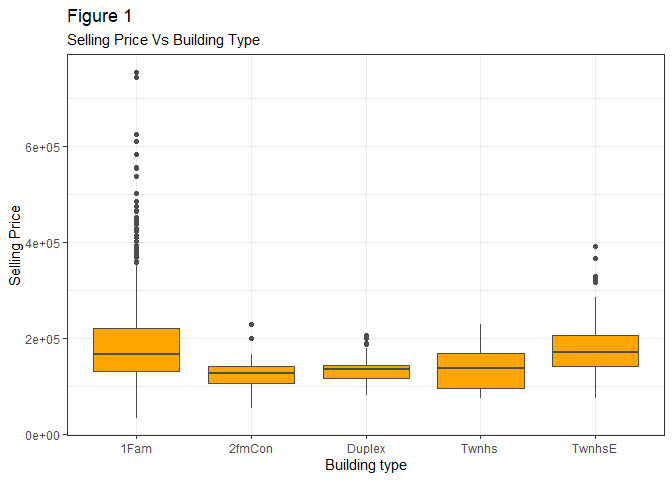

```r
ggplot(dt, aes(bld, sp))+
  geom_boxplot(show.legend = F, col="grey30", fill="orange") +
  theme_bw() +
  labs(
    x="Building type",
    y="Selling Price",
    title = "Figure 1",
    subtitle = "Selling Price Vs Building Type"
  )
```

I analyzed this boxplot to choose what Building types to include in my two category variable. As you can see, 1 Family units as well as Town Homes at the end of the unit outstand above the rest. So I made a column that considers as the same value when a house is in any of these two building types, if the house is in any of the other categories it’s considered non applicable for this variable. My reasoning is that these types of homes (1Fam and TwnshE) offer more privacy, thus are desired over the rest when purchasing a home.

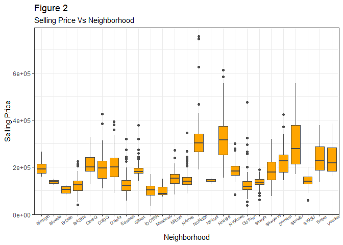

```r
ggplot(dt, aes(Neighborhood, sp))+
  geom_boxplot(show.legend = F, col="grey30", fill="orange") +
  theme_bw() +
  labs(
    x="Neighborhood",
    y="Selling Price",
    subtitle = "Selling Price Vs Neighborhood",
    title="Figure 2"
  ) +
  theme(axis.text.x = element_text(angle = 35, size=6))
```

The same thought process was considered here. If any house was within rich neighborhoods (StoneBr, NridgHt, NoRidge) they would be considered above others. So my neighborhood variable helps with that and was proven to be a significant variable in this model. See how these neighborhoods are above all the others and their quantiles surpass the rest. this means houses in these locations are of importance and higher prices.

[figure not shown]

```r
ggplot(dt, aes(SaleCondition, sp))+
  geom_boxplot(show.legend = F, col="grey30", fill="orange") +
  theme_bw() +
  labs(
    x="Neighborhood",
    y="Selling Price",
    subtitle = "Selling Price Vs Sale Condition",
    title="Figure 2"
  ) +
  theme(axis.text.x = element_text(angle = 0, size=8))
```

Here the variable was a little different to determine, however the boxplot helped me visualize first and then try to add it to my model. I say this because even though Family deals (where the house is bought and sold between family members) are similar in distribution to normal deals and allocative deals. It is not as significant as those two. Allocative, Normal, and Partial deals are the ones that have most significant higher prices in the model, thus they were added to the final model.

## Diagnostic Plots

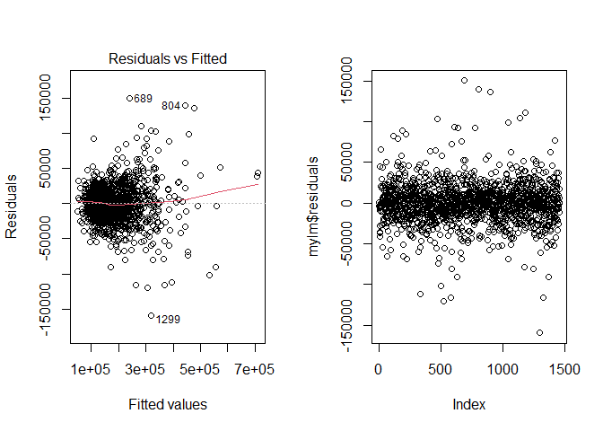

```r
par(mfrow=c(1,2))
plot(mylm,which=1)
plot(mylm$residuals)
```

Diagnostic plots look somewhat ok. Variance has the appearance of being inconstant, but it can be inconclusive. Because of all the other factors (large sample size, significance in the model, good validation) we will proceed with the analysis.

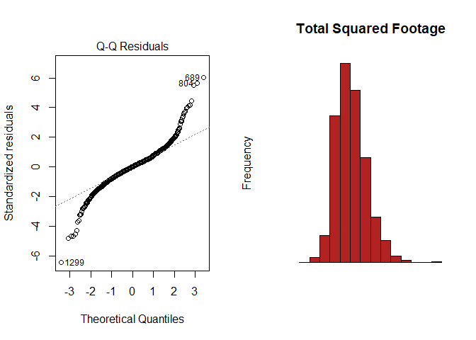

```r
par(mfrow=c(1,2))
plot(mylm,which=2)
hist(dt$tsf1, xlab="", xaxt='n', yaxt='n', main="Total Squared Footage", col="firebrick")
```

Normality however, can’t be denied to be abnormal. It has more of a heavy tailed, right skewed distribution (not helpful for analysis). As mentioned in the paragraph above, we have many reasons to still continue with the analysis.

As a note, I did try transforming the data, however I did not find any significance by doing so. That may have helped to make these diagnostics look better.

## Validations

```r
set.seed(13)

num_rows <- 1000 #1460 total
keep <- sample(1:nrow(dt), num_rows)

mytrain <- dt[keep, ]

mylm <- lm(sp ~  nbd + tsf1:oq + tsf1:oc1 + tsf1:nbd + bld1 + tsf1:kq + tsf1:bth + bdr + tsf1:bdr + sc + tsf1:ht + al + gr + tsf1:fp + LotArea , data=mytrain)

mytest <- dt[-keep, ] #Use this in the predict(..., newdata=mytest)

  yhcc <- predict(mylm, newdata=mytest)
  ybarcc <- mean(mytest$sp)
  SSTOcc <- sum( (mytest$sp - ybarcc)^2 )
  SSEcc <- sum( (mytest$sp - yhcc)^2 )
  rscc <- 1 - SSEcc/SSTOcc
  n <- length(mytest$sp) #sample size
  pcc  <- length(coef(mylm)) #num. parameters in model
  rscca <- 1 - (n-1)/(n-pcc)*SSEcc/SSTOcc

my_output_table2 <- data.frame(

  Model = c(

    "Square Footage Model"),

  `Original R2` = c(

    summary(mylm)$r.squared),

    #summary(bsalm)$r.squared),

  `Orig. Adj. R-squared` = c(

    summary(mylm)$adj.r.squared),

    #summary(bsalm)$adj.r.squared,


  `Validation R-squared` = c(

    rscc),

  `Validation Adj. R^2` = c(

    rscca))



colnames(my_output_table2) <- c(

  "Model", "Original $R^2$",

  "Original Adj. $R^2$",

  "Validation $R^2$",

  "Validation Adj. $R^2$")

kable(my_output_table2, escape=TRUE, digits=5)
```

| Model | Original $R^2$ | Original Adj. $R^2$ | Validation $R^2$ | Validation Adj. $R^2$ |
| --- | --- | --- | --- | --- |
| Square Footage Model | 0.89248 | 0.89085 | 0.91514 | 0.91227 |

This double validation process will help the model to be tested in a different environment to see how it performs. As seen in the table above, the square footage model performed better than in it’s initial environment, which is a good sign for the overall purpose of this analysis.

This means there is significance in the model, and that the approach to the true parameters of this data (if any), is not lost.

Validation for this model appears to have good results. Both validations worked out positively for the model at hand. The first one went down in R<sup>2</sup> by .01, the second one went up by .01. It seems that the average is the model’s original R<sup>2</sup> of .90 which makes the model reliable.

## Data Set

The data table for this regression model originally had less columns. I mutated some interesting columns and variables to make use of many on 2 categorical variables (the house has a garage or not, instead of the variable measuring the size of the garage or quality) this helped in the interpretation side of the model (See columns at the very end). While it might have taken some R<sup>2</sup> and significance in some terms. I considered it to be enough to bear while still having a good model to predict house selling prices.

```r
datatable(dt)
```

|  | Id | MSSubClass | MSZoning | LotFrontage | LotArea | Street | Alley | LotShape | LandContour | Utilities | LotConfig | LandSlope | Neighborhood | Condition1 | Condition2 | bld | HouseStyle | oq | oc | YearBuilt | YearRemodAdd | RoofStyle | RoofMatl | Exterior1st | Exterior2nd | MasVnrType | MasVnrArea | exq | exc | … |
| --- | --- | --- | --- | --- | --- | --- | --- | --- | --- | --- | --- | --- | --- | --- | --- | --- | --- | --- | --- | --- | --- | --- | --- | --- | --- | --- | --- | --- | --- | --- |
| 1 | 1 | 60 | RL | 65 | 8450 | Pave |  | Reg | Lvl | AllPub | Inside | Gtl | CollgCr | Norm | Norm | 1Fam | 2Story | 7 | 5 | 2003 | 2003 | Gable | CompShg | VinylSd | VinylSd | BrkFace | 196 | 8 | 6 | … |
| 2 | 2 | 20 | RL | 80 | 9600 | Pave |  | Reg | Lvl | AllPub | FR2 | Gtl | Veenker | Feedr | Norm | 1Fam | 1Story | 6 | 8 | 1976 | 1976 | Gable | CompShg | MetalSd | MetalSd | None | 0 | 6 | 6 | … |
| 3 | 3 | 60 | RL | 68 | 11250 | Pave |  | IR1 | Lvl | AllPub | Inside | Gtl | CollgCr | Norm | Norm | 1Fam | 2Story | 7 | 5 | 2001 | 2002 | Gable | CompShg | VinylSd | VinylSd | BrkFace | 162 | 8 | 6 | … |
| 4 | 4 | 70 | RL | 60 | 9550 | Pave |  | IR1 | Lvl | AllPub | Corner | Gtl | Crawfor | Norm | Norm | 1Fam | 2Story | 7 | 5 | 1915 | 1970 | Gable | CompShg | Wd Sdng | Wd Shng | None | 0 | 6 | 6 | … |
| 5 | 5 | 60 | RL | 84 | 14260 | Pave |  | IR1 | Lvl | AllPub | FR2 | Gtl | NoRidge | Norm | Norm | 1Fam | 2Story | 8 | 5 | 2000 | 2000 | Gable | CompShg | VinylSd | VinylSd | BrkFace | 350 | 8 | 6 | … |
| 6 | 6 | 50 | RL | 85 | 14115 | Pave |  | IR1 | Lvl | AllPub | Inside | Gtl | Mitchel | Norm | Norm | 1Fam | 1.5Fin | 5 | 5 | 1993 | 1995 | Gable | CompShg | VinylSd | VinylSd | None | 0 | 6 | 6 | … |
| 7 | 7 | 20 | RL | 75 | 10084 | Pave |  | Reg | Lvl | AllPub | Inside | Gtl | Somerst | Norm | Norm | 1Fam | 1Story | 8 | 5 | 2004 | 2005 | Gable | CompShg | VinylSd | VinylSd | Stone | 186 | 8 | 6 | … |
| 8 | 8 | 60 | RL |  | 10382 | Pave |  | IR1 | Lvl | AllPub | Corner | Gtl | NWAmes | PosN | Norm | 1Fam | 2Story | 7 | 6 | 1973 | 1973 | Gable | CompShg | HdBoard | HdBoard | Stone | 240 | 6 | 6 | … |
| 9 | 9 | 50 | RM | 51 | 6120 | Pave |  | Reg | Lvl | AllPub | Inside | Gtl | OldTown | Artery | Norm | 1Fam | 1.5Fin | 7 | 5 | 1931 | 1950 | Gable | CompShg | BrkFace | Wd Shng | None | 0 | 6 | 6 | … |
| 10 | 10 | 190 | RL | 50 | 7420 | Pave |  | Reg | Lvl | AllPub | Corner | Gtl | BrkSide | Artery | Artery | 2fmCon | 1.5Unf | 5 | 6 | 1939 | 1950 | Gable | CompShg | MetalSd | MetalSd | None | 0 | 6 | 6 | … |

[output cut: 1450 more lines]